# R Notebook

Vybrala sme si dataset iris. Jedná sa o dáta veľkosti okvetných lístkov 50 jedincov z každého druhu (3 druhy) rastliny Iris: Iris setosa, versicolor a virgnica.

```r
data(iris)
dataset<-iris
help(iris)
```

Najprv si zistíme koľko ridkov a stĺpcov sa vo vybranom datasete nachádza pomocou funkcie dim

```r
dim(dataset)
```

```
[1] 150   5
```

Ďalej zistíme, aké vlastnosti nám tieto dáta poskytujú

```r
sapply(dataset, class)
```

```
Sepal.Length  Sepal.Width Petal.Length  Petal.Width      Species
   "numeric"    "numeric"    "numeric"    "numeric"     "factor"
```

Zistiť presne čo head robí

|  | Sepal.Length | Sepal.Width | Petal.Length | Petal.Width | Species |
| --- | --- | --- | --- | --- | --- |
| 1 | 5.1 | 3.5 | 1.4 | 0.2 | setosa |
| 2 | 4.9 | 3.0 | 1.4 | 0.2 | setosa |
| 3 | 4.7 | 3.2 | 1.3 | 0.2 | setosa |
| 4 | 4.6 | 3.1 | 1.5 | 0.2 | setosa |
| 5 | 5.0 | 3.6 | 1.4 | 0.2 | setosa |
| 6 | 5.4 | 3.9 | 1.7 | 0.4 | setosa |

Premenná triedy je faktorom. Faktor je trieda, ktorá má viacero štítkov alebo úrovní triedy. Pozrime sa na úrovne.

```r
levels(dataset$Species)
```

```
[1] "setosa"     "versicolor" "virginica"
```

```r
cbind(freq=table(dataset$Species), percentage=percentage)
```

```
           freq percentage
setosa       50   33.33333
versicolor   50   33.33333
virginica    50   33.33333
```

Môžeme vidieť, že každá trieda má rovnaký počet prípadov (50 alebo 33% celej množiny údajov).

Následne sa pozrieme na zhrnutie každého atribútu.

```r
summary(dataset)
```

```
  Sepal.Length    Sepal.Width     Petal.Length    Petal.Width          Species
 Min.   :4.300   Min.   :2.000   Min.   :1.000   Min.   :0.100   setosa    :50
 1st Qu.:5.100   1st Qu.:2.800   1st Qu.:1.600   1st Qu.:0.300   versicolor:50
 Median :5.800   Median :3.000   Median :4.350   Median :1.300   virginica :50
 Mean   :5.843   Mean   :3.057   Mean   :3.758   Mean   :1.199
 3rd Qu.:6.400   3rd Qu.:3.300   3rd Qu.:5.100   3rd Qu.:1.800
 Max.   :7.900   Max.   :4.400   Max.   :6.900   Max.   :2.500
```

Teraz máme základnú myšlienku o údajoch. Budeme vytvárať jednoduché grafy pre jednotlivé atribúty a následne aj grafy viacrozmerné pre pochopenie vzťahov medzi atribútmi. Je užitočné, ak vizualizácia má spôsob, ako odkazovať len na vstupné atribúty a len výstupné atribúty. Hurá na boxploty.

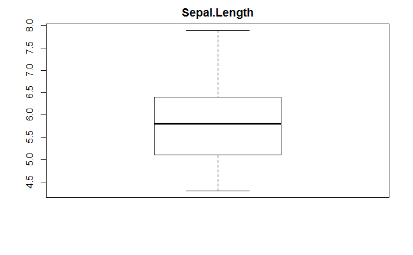

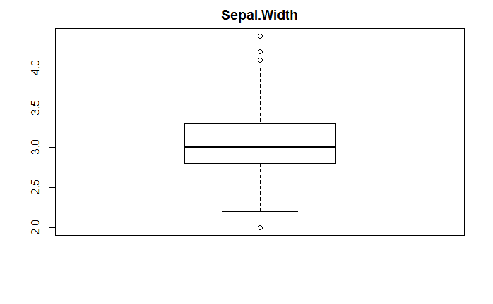

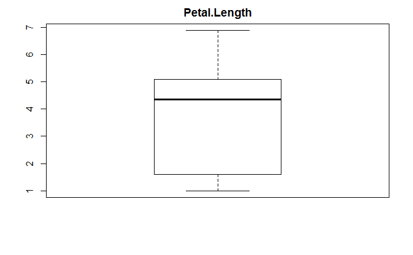

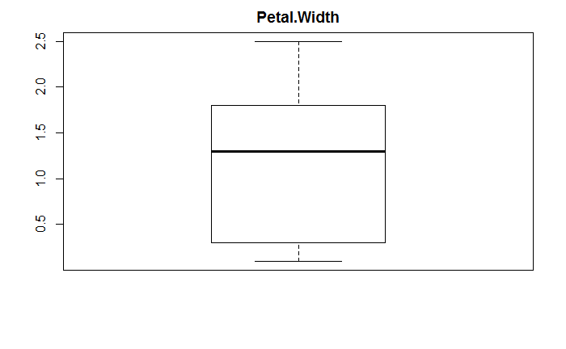

Môžeme vidieť, že všetky údaje majú podobný rozsah (a rovnaké jednotky centimetrov). Môžeme tiež vidieť, že Sepal.Width má pre túto vzorku niekoľko okrajových hodnôt.

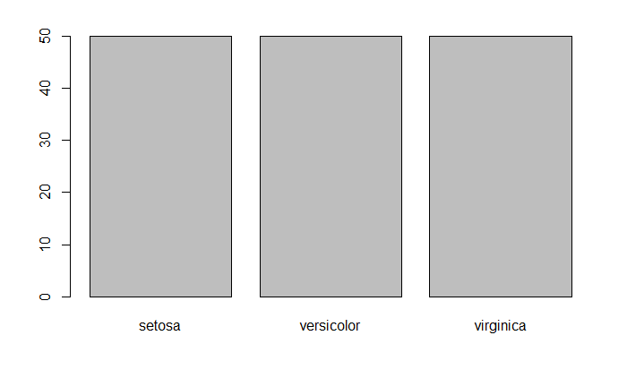

Toto nám dokazuje, že hodnoty sú rovnomerne rozdelené vo všetkých 3 druhoch rastliny.

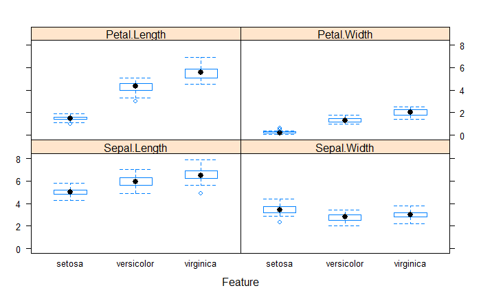

Tu vidíme, že pre každú triedu je rozdielna distribúcia hodnôt.

Následne použijeme density plot.

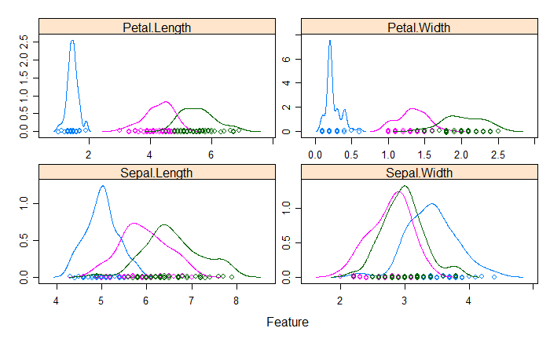

Podobne ako pri boxplotoch môžeme vidieť rozdiel v distribúcii artribútov podľa triedy. Taktiež pozorujeme Gaussovskú distribúciu (zvonová krivka) každého atribútu.

Využijeme možnosť použiť ggplot2, ktorý je veľmi výkonným balíkom založený na koncepte “Grammar of Graphics (gg)”. Umožňuje vytvoriť graf podľa konkrétnej syntaxe. Produkuje viac esteticky príjemné a výkonnejšie grafy ako základná grafika pomocou kompaktnejšieho kódu pre graf podobnej zložitosti.

```r
library(ggplot2)
```

Vytvoríme si bodový diagram

[figure not shown]

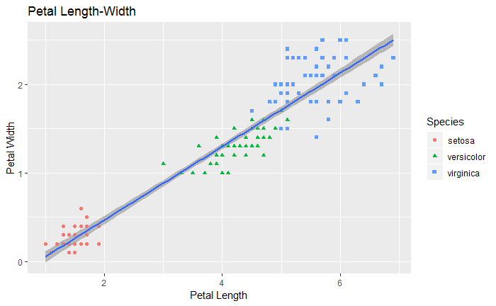

Môžeme vidieť prelínanie druhov versicolor a virginica.

Boxplot

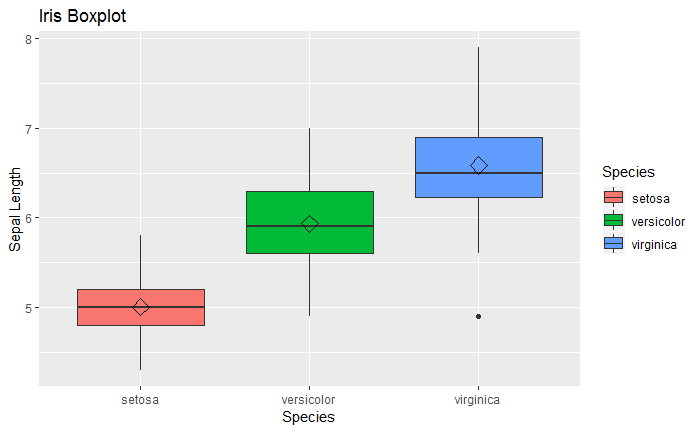

```r
library(ggthemes)
```

[output not shown]

Histogram

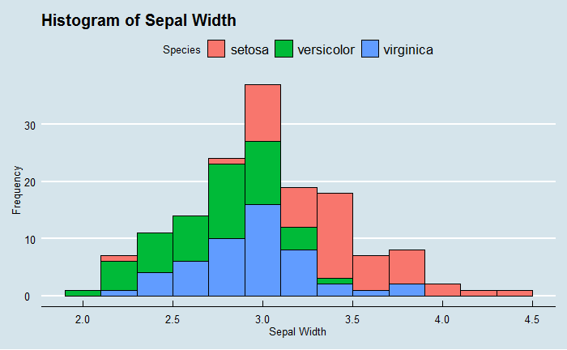

Faceting: vytváranie viacerých grafov na jednom výstupe.

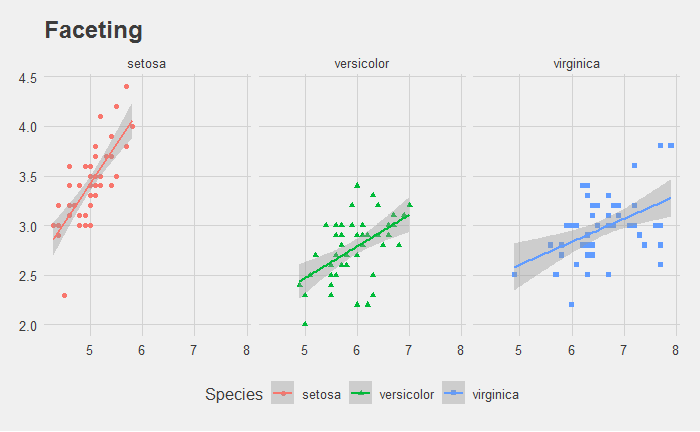

Budovanie modelu klasifikácie druhov rastliny IRIS

Hlavná otázka: Zaradenie jedinca na základe dát (sepal length/width, petal length/width) vzhľadom k datasetu k druhu ratsliny (Iris setosa/versicolor/virginica)

Použijeme Diskriminačnú analýzu

Model diskriminačnej analýzy sa vo všeobecnosti používa pre malé súbory údajov, ktoré by inak trpeli malým zaujatím vzorky v iných modeloch.

Rozložíme si dáta na 2 časti - tréningovú (trainset) a testovú (testset).

```r
library(caret)
```

Fitovanie a zobrazenie modelu LDA

```r
print(model.lda)
```

```
Linear Discriminant Analysis

120 samples
  4 predictor
  3 classes: 'setosa', 'versicolor', 'virginica'

No pre-processing
Resampling: Bootstrapped (25 reps)
Summary of sample sizes: 120, 120, 120, 120, 120, 120, ...
Resampling results:

  Accuracy   Kappa
  0.9578541  0.9356693
```

Overenie správnosti tréningovej množiny, resp. časti.

```r
confusionMatrix(pred,trainset$Species)
```

```
Confusion Matrix and Statistics

            Reference
Prediction   setosa versicolor virginica
  setosa         40          0         0
  versicolor      0         38         1
  virginica       0          2        39

Overall Statistics

               Accuracy : 0.975
                 95% CI : (0.9287, 0.9948)
    No Information Rate : 0.3333
    P-Value [Acc > NIR] : < 2.2e-16

                  Kappa : 0.9625
 Mcnemar's Test P-Value : NA

Statistics by Class:

                     Class: setosa Class: versicolor Class: virginica
Sensitivity                 1.0000            0.9500           0.9750
Specificity                 1.0000            0.9875           0.9750
Pos Pred Value              1.0000            0.9744           0.9512
Neg Pred Value              1.0000            0.9753           0.9873
Prevalence                  0.3333            0.3333           0.3333
Detection Rate              0.3333            0.3167           0.3250
Detection Prevalence        0.3333            0.3250           0.3417
Balanced Accuracy           1.0000            0.9688           0.9750
```

Vykonanie modelu na testovacej množine (časti)

```r
confusionMatrix(pred_test,testset$Species)
```

```
Confusion Matrix and Statistics

            Reference
Prediction   setosa versicolor virginica
  setosa         10          0         0
  versicolor      0         10         0
  virginica       0          0        10

Overall Statistics

               Accuracy : 1
                 95% CI : (0.8843, 1)
    No Information Rate : 0.3333
    P-Value [Acc > NIR] : 4.857e-15

                  Kappa : 1
 Mcnemar's Test P-Value : NA

Statistics by Class:

                     Class: setosa Class: versicolor Class: virginica
Sensitivity                 1.0000            1.0000           1.0000
Specificity                 1.0000            1.0000           1.0000
Pos Pred Value              1.0000            1.0000           1.0000
Neg Pred Value              1.0000            1.0000           1.0000
Prevalence                  0.3333            0.3333           0.3333
Detection Rate              0.3333            0.3333           0.3333
Detection Prevalence        0.3333            0.3333           0.3333
Balanced Accuracy           1.0000            1.0000           1.0000
```

Z štatistiky testovacej množiny vidíme Accuracy: 1 (presnosť), čo je najlepší možný výsledok.

Samozrejme na to, aby sme mohli potvrdiť že presnosť tejto štatistiky je najlepšia, by sme museli vytvoriť aj iné modely (napr. DTs = Decision Tree Classifiers, Gradient Boosting, Misclassified Observations).

Poznámka: Pri snahe o poslovenčenie grafov mi kód robil problémy a preto som sa tomu radšej vyhla.